# DiD in R

## Introduction

This exercise will help you learn about the recent DiD literature on settings with multiple periods and staggered treatment timing. We will examine the effects of Medicaid expansions on insurance coverage using publicly-available data from the ACS. This analysis is similar in spirit to that in [Carey, Miller, and Wherry (2020)](https://www.dropbox.com/s/mgunjcebpgnb939/Carey-et-al.pdf?dl=0), although they use confidential data.

## Package Setup

For R, you will need the following packages: `did`, `dplyr`, `fixest`, `bacondecomp`, and `haven`. For Stata, you will need `csdid`, `drdid`, `reghdfe`, and `bacondecomp`.

## Data

The provided datasets `ehec_data.dta` (for Stata) and `ehec_data.csv` (for R) contain a state-level panel dataset on health insurance coverage and Medicaid expansion. The variable `dins` shows the share of low-income childless adults with health insurance in the state. The variable `yexp2` gives the year that a state expanded Medicaid coverage under the Affordable Care Act, and is missing if the state never expanded. The variable `year` gives the year of the observation and the variable `stfips` is a state identifier. (The variable `W` is the sum of person-weights for the state in the ACS; for simplicity, we will treat all states equally and ignore the weights, although if you’d like an additional challenge feel free to re-do everything incorporating the population weights!)

## Questions

1. **Load the data**

Use the `haven::read_dta()` in R or `use` commands in Stata, respectively, to load the relevant dataset.

```r
library(dplyr)
library(did)
library(haven)
df <- haven::read_dta("https://raw.githubusercontent.com/Mixtape-Sessions/Advanced-DID/main/Exercises/Data/ehec_data.dta")
```

### Understand the data & visualize policy rollout

```r
# This section standardizes the key columns and produces quick visuals
# tailored to this dataset (state-year panel with Medicaid expansion timing).

suppressPackageStartupMessages({
  library(dplyr); library(tidyr); library(ggplot2); library(rlang); library(knitr)
})

# 1) Map to standardized names for clarity
df_here <- df
cols <- list(
  id          = "stfips",   # state FIPS
  time        = "year",
  y           = "dins",     # outcome used in the exercise
  first_treat = "yexp2",    # expansion year; NA implies "never (in sample window)"
  D           = NULL        # not needed because we have first_treat
)

id_sym  <- sym(cols$id);  time_sym <- sym(cols$time);  y_sym <- sym(cols$y)
ft_sym  <- sym(cols$first_treat)

derive_first_treat <- function(df, id, time, D) {
  df %>% arrange({{id}}, {{time}}) %>% group_by({{id}}) %>%
    mutate(first.treat = dplyr::if_else(all({{D}} == 0 | is.na({{D}})), 0L,
                                        suppressWarnings(min({{time}}[{{D}} == 1], na.rm = TRUE)) %>% as.integer())) %>%
    ungroup()
}

# Standardize columns: id, time, y, first.treat, D
df_std <- df_here %>%
  rename(id = !!id_sym, time = !!time_sym, y = !!y_sym, first.treat = !!ft_sym) %>%
  mutate(first.treat = ifelse(is.na(first.treat) | first.treat == 0, 0L, as.integer(first.treat)),
         D = ifelse(first.treat == 0L, 0L, as.integer(time >= first.treat))) %>%
  arrange(id, time) %>%
  mutate(across(c(id, time), as.integer))

# Event time (NA for never-treated); status for plots
df_std <- df_std %>%
  mutate(event_time = ifelse(first.treat == 0L, NA_integer_, time - first.treat),
         status = ifelse(D == 1, "treated", "untreated"))

# 2) Quick overview
n_obs  <- nrow(df_std); n_id <- dplyr::n_distinct(df_std$id); n_time <- dplyr::n_distinct(df_std$time)
dup_ct <- df_std %>% count(id, time) %>% filter(n > 1) %>% nrow()
cat("Rows:", n_obs, " | States:", n_id, " | Years:", n_time, " | Duplicate (id,time) rows:", dup_ct, "\\n")
```

```
## Rows: 552  | States: 46  | Years: 12  | Duplicate (id,time) rows: 0 \n
```

```r
knitr::kable(head(df_std, 6), caption = "First 6 standardized rows (id, time, y, first.treat, D)")
```

First 6 standardized rows (id, time, y, first.treat, D)

| id | time | y | first.treat | W | D | event_time | status |
| --- | --- | --- | --- | --- | --- | --- | --- |
| 1 | 2008 | 0.6814122 | 0 | 613156 | 0 | NA | untreated |
| 1 | 2009 | 0.6580621 | 0 | 613156 | 0 | NA | untreated |
| 1 | 2010 | 0.6313651 | 0 | 613156 | 0 | NA | untreated |
| 1 | 2011 | 0.6563886 | 0 | 613156 | 0 | NA | untreated |
| 1 | 2012 | 0.6708115 | 0 | 613156 | 0 | NA | untreated |
| 1 | 2013 | 0.6521544 | 0 | 613156 | 0 | NA | untreated |

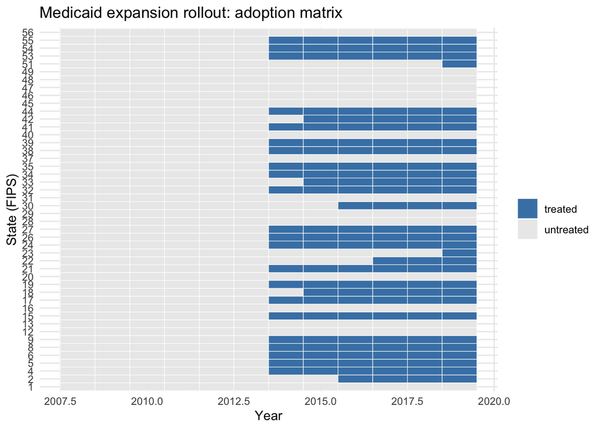

```r
# 3) Rollout visuals

# (a) Adoption matrix (treated vs untreated)
ggplot(df_std, aes(x = time, y = factor(id))) +
  geom_tile(aes(fill = status), color = "white") +
  scale_fill_manual(values = c("treated" = "steelblue", "untreated" = "grey92")) +
  labs(x = "Year", y = "State (FIPS)", fill = "", title = "Medicaid expansion rollout: adoption matrix") +
  theme_minimal(base_size = 11)
```

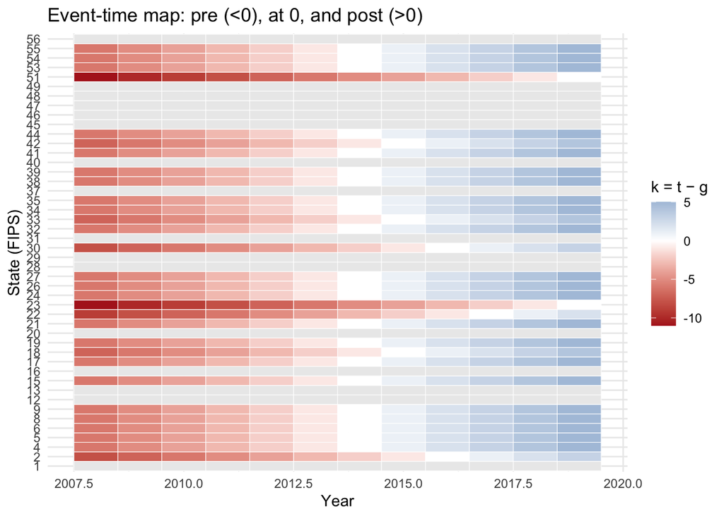

```r
# (b) Event-time heatmap (k = t − g)
ggplot(df_std, aes(x = time, y = factor(id))) +
  geom_tile(aes(fill = event_time), color = "white") +
  scale_fill_gradient2(low = "firebrick", mid = "white", high = "steelblue",
                       midpoint = 0, na.value = "grey92") +
  labs(x = "Year", y = "State (FIPS)", fill = "k = t − g",
       title = "Event-time map: pre (<0), at 0, and post (>0)") +
  theme_minimal(base_size = 11)
```

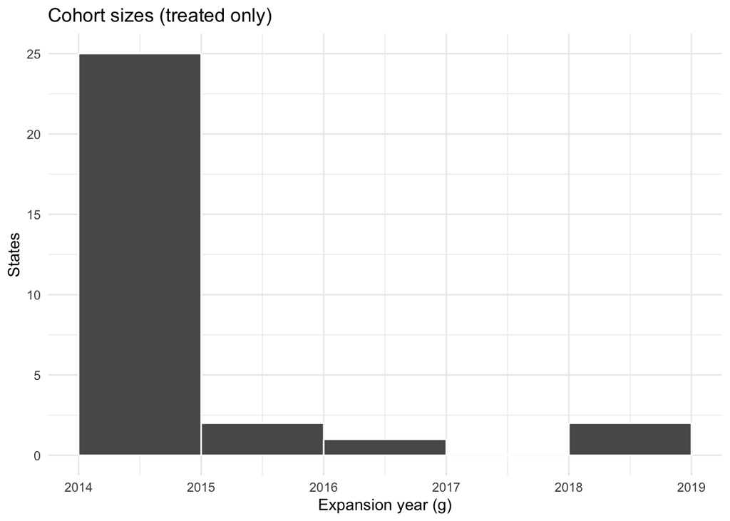

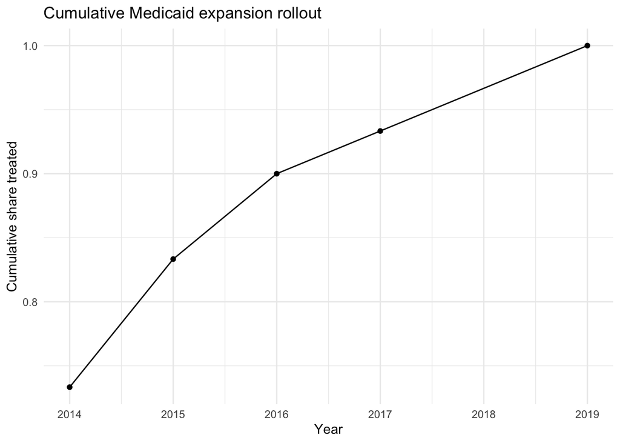

```r
# (c) Cohort sizes & cumulative expansion
coh <- df_std %>% distinct(id, first.treat) %>% filter(first.treat > 0)
p_hist <- ggplot(coh, aes(first.treat)) +
  geom_histogram(binwidth = 1, boundary = 0, color = "white") +
  labs(x = "Expansion year (g)", y = "States", title = "Cohort sizes (treated only)") +
  theme_minimal(base_size = 11)

cum_adopt <- coh %>% count(first.treat) %>% arrange(first.treat) %>%
  mutate(cum = cumsum(n) / sum(n))
p_cum <- ggplot(cum_adopt, aes(first.treat, cum)) +
  geom_line() + geom_point() +
  labs(x = "Year", y = "Cumulative share treated", title = "Cumulative Medicaid expansion rollout") +
  theme_minimal(base_size = 11)

p_hist; p_cum
```

2. **Estimate the ATT(g,t) using Callaway and Sant’Anna’s estimator**

Use the `attgt` function in the did package (R) or the `csdid` function in the csdid package (Stata) to estimate the group-time specific ATTs for the outcome `dins`. In R, I recommend using the control group option “notyettreated”, which uses as a comparison group all units who are not-yet-treated at a given period (including never-treated units). In Stata, use the option `, notyet`. (For fun, you’re welcome to also try out using “nevertreated” units as the control). Hint: replace missing values of `yexp2` to some large number (say, 3000) for the the did package to incorporate the never-treated units as controls.

```r
cs_results <- att_gt(
  yname = "dins",
  tname = "year",
  idname = "stfips",
  gname = "yexp2",
  data = df %>% mutate(yexp2 = ifelse(is.na(yexp2), 3000, yexp2)),
  control_group = "notyettreated"
)
```

For R users, apply the `summary` command to the results from the `att_gt` command. For Stata users, this should already be reported as a result of `csdid` command. After applying the correct command, you should have a table with estimates of the ATT(g,t) – that is, average treatment effects for a given “cohort” first-treated in period g at each time t. For example, ATT(2014,2015) gives the treatment effect in 2015 for the cohort first treated in 2014.

```r
summary(cs_results)
```

```
##
## Call:
## att_gt(yname = "dins", tname = "year", idname = "stfips", gname = "yexp2",
##     data = df %>% mutate(yexp2 = ifelse(is.na(yexp2), 3000, yexp2)),
##     control_group = "notyettreated")
##
## Reference: Callaway, Brantly and Pedro H.C. Sant'Anna.  "Difference-in-Differences with Multiple Time Periods." Journal of Econometrics, Vol. 225, No. 2, pp. 200-230, 2021. <https://doi.org/10.1016/j.jeconom.2020.12.001>, <https://arxiv.org/abs/1803.09015>
##
## Group-Time Average Treatment Effects:
##  Group Time ATT(g,t) Std. Error [95% Simult.  Conf. Band]
##   2014 2009  -0.0065     0.0053       -0.0566      0.0436
##   2014 2010   0.0111     0.0065       -0.0509      0.0732
##   2014 2011   0.0015     0.0056       -0.0521      0.0552
##   2014 2012   0.0016     0.0059       -0.0545      0.0578
##   2014 2013   0.0009     0.0072       -0.0675      0.0693
```

[output cut: 55 more lines]

3. **Compare to DiD estimates calculated by hand**

To understand how these ATT(g,t) estimates are constructed, we will manually compute one of them by hand. For simplicity, let’s focus on ATT(2014, 2014), the treatment effect for the first treated cohort (2014) in the year that they’re treated (2014). Create an indicator variable D for whether a unit is first-treated in 2014. Calculate the conditional mean of `dins` for the years 2013 and 2014 for units with D=1 and units with D=0 (i.e. calculate 4 means, for each combination of year and D). Manually compute the 2x2 DiD between D=1 and D=0 and 2013 and 2014. If you did it right, this should line up exactly with the ATT(g,t) estimate you got from the CS package! (Bonus: If you’re feeling ambitious, you can verify by hand that the other ATT(g,t) estimates from the CS package also correspond with simple 2x2 DiDs that you can compute by hand)

```r
# Compute the ATT(2014,2014) by hand
ytable <-
  df %>%
  filter(year %in% c(2013, 2014)) %>%
  mutate(treated = case_when(
    yexp2 == 2014 ~ 1,
    is.na(yexp2) | yexp2 > 2014 ~ 0
  )) %>%
  group_by(treated, year) %>%
  summarise(dins = mean(dins))
with(ytable, {
  (dins[year == 2014 & treated == 1] - dins[year == 2013 & treated == 1]) -
    (dins[year == 2014 & treated == 0] - dins[year == 2013 & treated == 0])
})
```

```
## [1] 0.04670243
```

4. **Aggregate the $ATT(g,t)$**

We are often interested in a summary of the ATT(g,t)’s.

In R, use the `aggte` command with option `type = "dynamic"` to compute “event-study” parameters. These are averages of the ATT(g,t) for cohorts at a given lag from treatment — for example, the estimate for event-time 3 gives an average of parameters of the form ATT(g,g+3), i.e. treatment effects 3 periods after units were first treated. You can use the `ggdid` command to plot the relevant event-study.

In Stata, use the commands `qui: estat event` followed by `csdid_plot`.

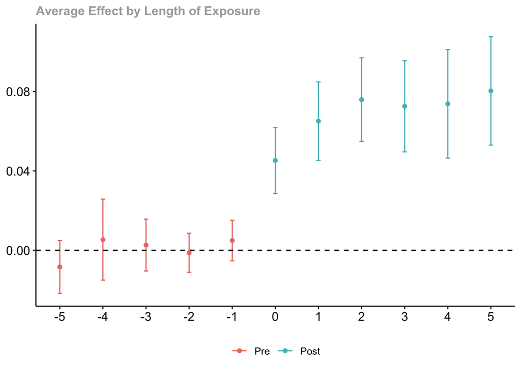

```r
es <- aggte(cs_results,
  type = "dynamic",
  min_e = -5, max_e = 5
)

ggdid(es)
```

You can also calculate overall summary parameters. E.g, in R, using `aggte` with the option `type = "simple"` takes a simple weighted average of the ATT(g,t), weighting proportional to cohort sizes. In Stata, you can use `estat simple`.

```r
aggte(cs_results, type = "simple")
```

```
##
## Call:
## aggte(MP = cs_results, type = "simple")
##
## Reference: Callaway, Brantly and Pedro H.C. Sant'Anna.  "Difference-in-Differences with Multiple Time Periods." Journal of Econometrics, Vol. 225, No. 2, pp. 200-230, 2021. <https://doi.org/10.1016/j.jeconom.2020.12.001>, <https://arxiv.org/abs/1803.09015>
##
##
##    ATT    Std. Error     [ 95%  Conf. Int.]
##  0.068        0.0078     0.0526      0.0834 *
##
##
## ---
## Signif. codes: `*' confidence band does not cover 0
##
## Control Group:  Not Yet Treated,  Anticipation Periods:  0
## Estimation Method:  Doubly Robust
```

5. **Compare to TWFE estimates (part 1)**

Estimate the OLS regression specification

$$Y_{it} = \alpha_i + \lambda_t + D_{it} \beta +\epsilon_{it},$$

where $D_{it}$ is an indicator for whether unit $i$ was treated in period $t$. How does the estimate for $\hat{\beta}$ compare to the simple weighted average you got from Callaway and Sant’Anna? (Don’t forget to cluster your SEs at the state level!)

```r
library(fixest)
# Create a post-treatment indicator
df <- df %>% mutate(postTreated = !is.na(yexp2) & year >= yexp2)

# Run static TWFE, with SEs clustered at the state level
twfe_static <- feols(dins ~ postTreated | stfips + year, data = df, cluster = "stfips")
summary(twfe_static)
```

```
## OLS estimation, Dep. Var.: dins
## Observations: 552
## Fixed-effects: stfips: 46,  year: 12
## Standard-errors: Clustered (stfips)
##                 Estimate Std. Error t value   Pr(>|t|)
## postTreatedTRUE 0.070321   0.007401 9.50152 2.5169e-12 ***
## ---
## Signif. codes:  0 '***' 0.001 '**' 0.01 '*' 0.05 '.' 0.1 ' ' 1
## RMSE: 0.021082     Adj. R2: 0.93835
##                  Within R2: 0.426746
```

6. **Explain this result using the Bacon decomposition**

You probably noticed that the static TWFE estimate and the simple-weighted average from C&S were fairly similar. The reason for that is that in this example, there are a fairly large number of never-treated units, and so TWFE mainly puts weight on “clean comparisons”. We can see this by using the `Bacon decomposition`, which shows how much weight static TWFE is putting on clean versus forbidden comparisons. In R, use the `bacon()` command to estimate the weights that TWFE puts on each of the types of comparisons. The first data-frame returned by the command shows how much weight OLS put on the three types of comparisons. In Stata, use the command `bacondecomp` (Note that you should use the `ddetail` and `stub()` options in the command but the weights that the Stata version produce are wrong). How much weight is put on forbidden comparisons here (i.e. comparisons of ‘Later vs Earlier’)?

```r
library(bacondecomp)
bacon(dins ~ postTreated,
  data = df,
  id_var = "stfips",
  time_var = "year"
)
```

```
##                       type  weight avg_est
## 1 Earlier vs Later Treated 0.14911 0.06983
## 2 Later vs Earlier Treated 0.05827 0.04486
## 3     Treated vs Untreated 0.79262 0.07228
```

```
##    treated untreated    estimate       weight                     type
## 2     2016     99999 0.082728773 0.0502256229     Treated vs Untreated
## 3     2014     99999 0.074935691 0.6215420836     Treated vs Untreated
## 4     2015     99999 0.046864475 0.0824014126     Treated vs Untreated
## 5     2017     99999 0.102274094 0.0211889347     Treated vs Untreated
## 6     2019     99999 0.030943646 0.0172650579     Treated vs Untreated
## 9     2014      2016 0.050191048 0.0258975868 Earlier vs Later Treated
## 10    2015      2016 0.004156228 0.0020600353 Earlier vs Later Treated
## 11    2017      2016 0.031975667 0.0002942908 Later vs Earlier Treated
## 12    2019      2016 0.005429020 0.0005885815 Later vs Earlier Treated
## 14    2016      2014 0.054292531 0.0172650579 Later vs Earlier Treated
## 16    2015      2014 0.030656579 0.0161859918 Later vs Earlier Treated
## 17    2017      2014 0.077060485 0.0097115951 Later vs Earlier Treated
## 18    2019      2014 0.025483405 0.0107906612 Later vs Earlier Treated
## 20    2016      2015 0.041763062 0.0011771630 Later vs Earlier Treated
## 21    2014      2015 0.066569262 0.0194231901 Earlier vs Later Treated
## 23    2017      2015 0.063993540 0.0008828723 Later vs Earlier Treated
## 24    2019      2015 0.027470457 0.0011771630 Later vs Earlier Treated
## 26    2016      2017 0.014518637 0.0007847754 Earlier vs Later Treated
## 27    2014      2017 0.048755447 0.0194231901 Earlier vs Later Treated
## 28    2015      2017 0.008627171 0.0020600353 Earlier vs Later Treated
## 30    2019      2017 0.033588931 0.0001961938 Later vs Earlier Treated
## 32    2016      2019 0.090774537 0.0047086521 Earlier vs Later Treated
## 33    2014      2019 0.088170864 0.0647439670 Earlier vs Later Treated
## 34    2015      2019 0.061097391 0.0082401413 Earlier vs Later Treated
## 35    2017      2019 0.110885473 0.0017657446 Earlier vs Later Treated
```

7. **Compare to TWFE estimates (part 2)**

To see a situation where negative weights can matter (somewhat) more, drop from your dataset all the observations that are never-treated. Re-run the Callaway and Sant’Anna and TWFE estimates like you did before on this modified data-set. How does the TWFE estimate compare to the simple weighted average (or the average of the event-study coefficients) now?

```r
## Re-run the CS results dropping never-treated units
cs_results <- att_gt(
  yname = "dins",
  tname = "year",
  idname = "stfips",
  gname = "yexp2",
  data = df %>% filter(!is.na(yexp2)),
  control_group = "notyettreated"
)

aggte(cs_results, type = "simple")
```

```
##
## Call:
## aggte(MP = cs_results, type = "simple")
##
## Reference: Callaway, Brantly and Pedro H.C. Sant'Anna.  "Difference-in-Differences with Multiple Time Periods." Journal of Econometrics, Vol. 225, No. 2, pp. 200-230, 2021. <https://doi.org/10.1016/j.jeconom.2020.12.001>, <https://arxiv.org/abs/1803.09015>
##
##
##     ATT    Std. Error     [ 95%  Conf. Int.]
##  0.0728        0.0097     0.0537      0.0919 *
##
##
## ---
## Signif. codes: `*' confidence band does not cover 0
##
## Control Group:  Not Yet Treated,  Anticipation Periods:  0
## Estimation Method:  Doubly Robust
```

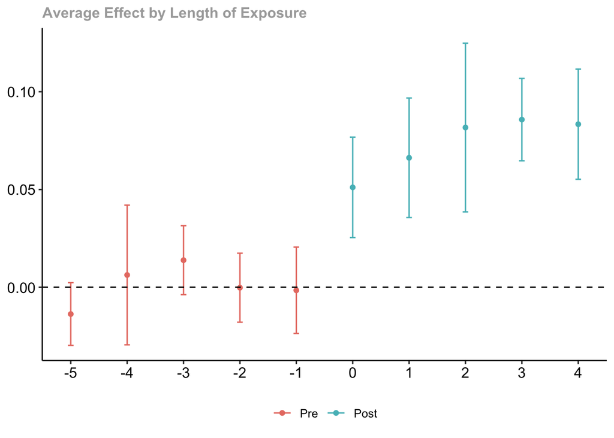

```r
es <- aggte(cs_results,
  type = "dynamic",
  min_e = -5, max_e = 5
)

ggdid(es)
```

```r
# Re-run TWFE dropping the never-treated units
twfe_static <- feols(dins ~ postTreated | stfips + year,
  data = df %>% filter(!is.na(yexp2)),
  cluster = "stfips"
)
summary(twfe_static)
```

```
## OLS estimation, Dep. Var.: dins
## Observations: 360
## Fixed-effects: stfips: 30,  year: 12
## Standard-errors: Clustered (stfips)
##                 Estimate Std. Error t value   Pr(>|t|)
## postTreatedTRUE 0.062817   0.007653  8.2084 4.7423e-09 ***
## ---
## Signif. codes:  0 '***' 0.001 '**' 0.01 '*' 0.05 '.' 0.1 ' ' 1
## RMSE: 0.022654     Adj. R2: 0.934671
##                  Within R2: 0.200545
```

8. **Run the Bacon decomposition (part 2)**

Re-run the Bacon decomposition on the modified dataset. How much weight is put on “forbidden comparisons” now?

```r
bacon(dins ~ postTreated,
  data = df %>% filter(!is.na(yexp2)),
  id_var = "stfips",
  time_var = "year"
)
```

```
##                       type  weight avg_est
## 1 Earlier vs Later Treated 0.71902 0.06983
## 2 Later vs Earlier Treated 0.28098 0.04486
```

```
##    treated untreated    estimate       weight                     type
## 2     2014      2016 0.050191048 0.1248817408 Earlier vs Later Treated
## 3     2015      2016 0.004156228 0.0099337748 Earlier vs Later Treated
## 4     2017      2016 0.031975667 0.0014191107 Later vs Earlier Treated
## 5     2019      2016 0.005429020 0.0028382214 Later vs Earlier Treated
## 6     2016      2014 0.054292531 0.0832544939 Later vs Earlier Treated
## 8     2015      2014 0.030656579 0.0780510880 Later vs Earlier Treated
## 9     2017      2014 0.077060485 0.0468306528 Later vs Earlier Treated
## 10    2019      2014 0.025483405 0.0520340587 Later vs Earlier Treated
## 11    2016      2015 0.041763062 0.0056764428 Later vs Earlier Treated
## 12    2014      2015 0.066569262 0.0936613056 Earlier vs Later Treated
## 14    2017      2015 0.063993540 0.0042573321 Later vs Earlier Treated
## 15    2019      2015 0.027470457 0.0056764428 Later vs Earlier Treated
## 16    2016      2017 0.014518637 0.0037842952 Earlier vs Later Treated
## 17    2014      2017 0.048755447 0.0936613056 Earlier vs Later Treated
## 18    2015      2017 0.008627171 0.0099337748 Earlier vs Later Treated
## 20    2019      2017 0.033588931 0.0009460738 Later vs Earlier Treated
## 21    2016      2019 0.090774537 0.0227057711 Earlier vs Later Treated
## 22    2014      2019 0.088170864 0.3122043519 Earlier vs Later Treated
## 23    2015      2019 0.061097391 0.0397350993 Earlier vs Later Treated
## 24    2017      2019 0.110885473 0.0085146641 Earlier vs Later Treated
```

9. **Even bigger TWFE problems**

In the last question, you saw an example where TWFE put a lot of weight on “forbidden comparisons”. However, the estimates from the forbidden comparisons were not so bad because the treatment effects were relatively stable over time (the post-treatment event-study coefficients are fairly flat). To see how dynamic treatment effects can make the problem worse, create a variable `relativeTime` that gives the number of periods since a unit has been treated. Create a new outcome variable `dins2` that adds 0.01 times `relativeTime` to `dins` for observations that have already been treated (i.e., we add in some dynamic treatment effects that increase by 0.01 in each period after a unit is treated). Re-run the Callaway & Sant’Anna and TWFE estimates and the Bacon decomp using the dataset from the previous question and the `dins2` variable. How do the differences between C&S and TWFE compare to before?

```r
## Re-run the CS results dropping never-treated units and adding dynamic TEs
cs_results <- att_gt(
  yname = "dins2",
  tname = "year",
  idname = "stfips",
  gname = "yexp2",
  data = df %>%
    filter(!is.na(yexp2)) %>%
    mutate(relativeTime = year - yexp2) %>%
    mutate(dins2 = dins + pmax(relativeTime, 0) * 0.01),
  control_group = "notyettreated"
)

aggte(cs_results, type = "simple")
```

```
##
## Call:
## aggte(MP = cs_results, type = "simple")
##
## Reference: Callaway, Brantly and Pedro H.C. Sant'Anna.  "Difference-in-Differences with Multiple Time Periods." Journal of Econometrics, Vol. 225, No. 2, pp. 200-230, 2021. <https://doi.org/10.1016/j.jeconom.2020.12.001>, <https://arxiv.org/abs/1803.09015>
##
##
##     ATT    Std. Error     [ 95%  Conf. Int.]
##  0.0917          0.01     0.0721      0.1113 *
##
##
## ---
## Signif. codes: `*' confidence band does not cover 0
##
## Control Group:  Not Yet Treated,  Anticipation Periods:  0
## Estimation Method:  Doubly Robust
```

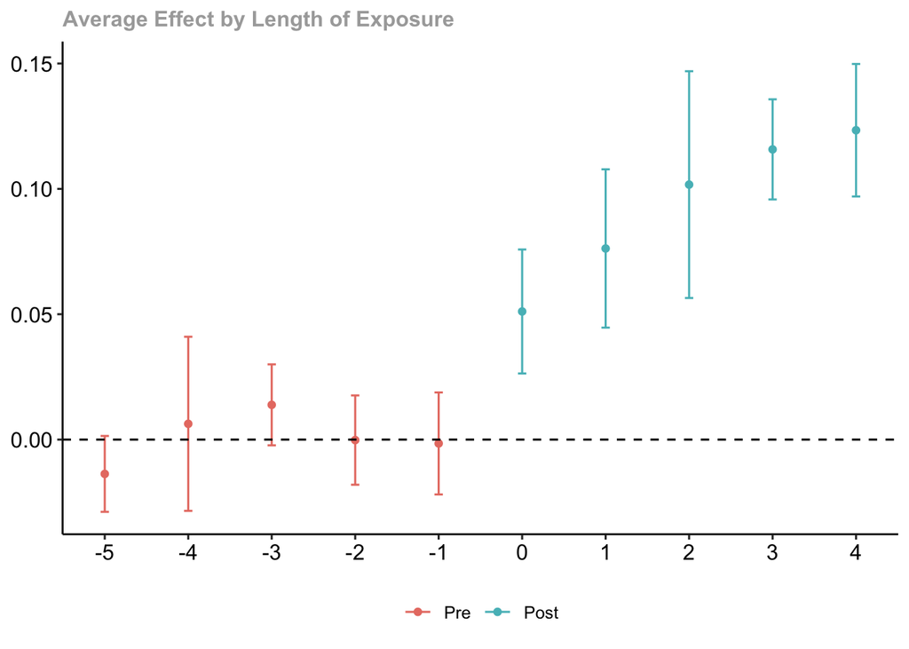

```r
es <- aggte(cs_results,
  type = "dynamic",
  min_e = -5, max_e = 5
)

ggdid(es)
```

```r
# Re-run TWFE dropping the never-treated units and adding dynamic TEs
twfe_static <- feols(dins2 ~ postTreated | stfips + year,
  data = df %>%
    filter(!is.na(yexp2)) %>%
    mutate(relativeTime = year - yexp2) %>%
    mutate(dins2 = dins + pmax(relativeTime, 0) * 0.01),
  cluster = "stfips"
)
summary(twfe_static)
```

```
## OLS estimation, Dep. Var.: dins2
## Observations: 360
## Fixed-effects: stfips: 30,  year: 12
## Standard-errors: Clustered (stfips)
##                 Estimate Std. Error t value   Pr(>|t|)
## postTreatedTRUE 0.066663   0.010135 6.57752 3.3102e-07 ***
## ---
## Signif. codes:  0 '***' 0.001 '**' 0.01 '*' 0.05 '.' 0.1 ' ' 1
## RMSE: 0.024051     Adj. R2: 0.941205
##                  Within R2: 0.200399
```

```r
bacon(dins2 ~ postTreated,
  data = df %>%
    filter(!is.na(yexp2)) %>%
    mutate(relativeTime = year - yexp2) %>%
    mutate(dins2 = dins + pmax(relativeTime, 0) * 0.01),
  id_var = "stfips",
  time_var = "year"
)
```

```
##                       type  weight avg_est
## 1 Earlier vs Later Treated 0.71902 0.08196
## 2 Later vs Earlier Treated 0.28098 0.02751
```

```
##    treated untreated     estimate       weight                     type
## 2     2014      2016  0.055191048 0.1248817408 Earlier vs Later Treated
## 3     2015      2016  0.004156228 0.0099337748 Earlier vs Later Treated
## 4     2017      2016  0.021975667 0.0014191107 Later vs Earlier Treated
## 5     2019      2016 -0.014570980 0.0028382214 Later vs Earlier Treated
## 6     2016      2014  0.039292531 0.0832544939 Later vs Earlier Treated
## 8     2015      2014  0.020656579 0.0780510880 Later vs Earlier Treated
## 9     2017      2014  0.057060485 0.0468306528 Later vs Earlier Treated
## 10    2019      2014 -0.004516595 0.0520340587 Later vs Earlier Treated
## 11    2016      2015  0.031763062 0.0056764428 Later vs Earlier Treated
## 12    2014      2015  0.066569262 0.0936613056 Earlier vs Later Treated
## 14    2017      2015  0.048993540 0.0042573321 Later vs Earlier Treated
## 15    2019      2015  0.002470457 0.0056764428 Later vs Earlier Treated
## 16    2016      2017  0.014518637 0.0037842952 Earlier vs Later Treated
## 17    2014      2017  0.058755447 0.0936613056 Earlier vs Later Treated
## 18    2015      2017  0.013627171 0.0099337748 Earlier vs Later Treated
## 20    2019      2017  0.018588931 0.0009460738 Later vs Earlier Treated
## 21    2016      2019  0.100774537 0.0227057711 Earlier vs Later Treated
## 22    2014      2019  0.108170864 0.3122043519 Earlier vs Later Treated
## 23    2015      2019  0.076097391 0.0397350993 Earlier vs Later Treated
## 24    2017      2019  0.115885473 0.0085146641 Earlier vs Later Treated
```